# Final Project

Author

Sagnik Chand

Published

December 31, 2023

## Unraveling the Scholastic Success Equation: Exploring the Impact of School Investment, Teacher Salaries, and Graduation Rates on SAT Triumphs in Massachusetts District Schools - Sagnik Chand

**Introduction**

Every parent and teacher wants the best education possible for their high school students. Every taxpayer and administrator wants more return for his or her dollar. Every student wants to have a satisfying high school experience, consisting of an enjoyable time while gaining knowledge. The relationship between educational expenditure and student achievement has long been debated in educational research. Hanushek’s seminal reviews have challenged the conventional wisdom, suggesting that increased spending on public education does not necessarily translate into improved educational outcomes. Despite substantial increases in per-pupil expenditure and average teacher salaries over the past few decades, student performance on standardized tests has remained stagnant. This raises questions about the efficacy of the current education system and the allocation of resources.

Moreover, the existence of achievement gaps among students has been a persistent concern for educators and policymakers. Factors such as family background (Arteaga and Glewwe (2019), Berkowitz et al. (2017), Blandin (2017), Goddard et al. (2017)), racial and ethnic diversity (Bond & Lang, 2018; Gagnon & Mattingly, 2018; Mocombe, 2018; Taggart, 2018), socioeconomic status (Gearin et al., 2018; Rowe & Perry, 2020; Li et al., 2017), and school funding levels have all been implicated in contributing to these disparities (Baker, 2016; Hodges, 2018; Johnson & Vesely, 2017; Rauscher, 2018). In Massachusetts, a state renowned for its academic excellence, the presence of significant achievement gaps within school districts underscores the complexity of the issue.

This research study aims to explore the relationship between various factors, including per pupil expenditure, average teacher salaries, student graduation rates, and Scholastic Aptitude Testing (SAT) scores in Massachusetts elementary schools. By scrutinizing the interplay among these variables, the goal is to uncover insights into how school funding levels and other factors impact academic achievement. Ultimately, this analysis seeks to provide valuable insights for evidence-based policymaking geared towards fostering educational equity and excellence across Massachusetts school districts.

My research question holds significant importance due to its potential implications for educational policy and practice. By examining the relationship between per pupil expenditure, average teacher salaries, student graduation rates, and Scholastic Aptitude Testing (SAT) scores, we aim to gain insights into the effectiveness of resource allocation in Massachusetts schools. Understanding whether higher funding levels, along with other factors, correspond to improved academic outcomes can inform decisions aimed at optimizing educational investments and promoting student success. This investigation not only addresses a critical aspect of education equity but also offers insights that can drive evidence-based interventions to enhance the quality of education in Massachusetts schools (Minahan, Julie, 2021; Coate, Douglas & VanderHoff, James, 2000).

**Research Question**

How do Scholastic Aptitude Testing (SAT) scores differ when compared to per pupil expenditure costs, average teacher salaries, and student graduation rates of district schools in Massachusetts?

**Hypothesis**

Previous research has extensively examined hypotheses regarding the relationship between school funding levels, average teacher salaries, student graduation rates, and student achievement in Massachusetts elementary schools. These include assertions such as the lack of significant differences in standardized testing scores or per pupil expenditure rates based on school funding levels (Minahan, Julie, 2021). Additionally, studies have investigated the impact of district-level variables like expenditures per pupil, average classroom teacher salary, and student graduation rates on student achievement (Kopco, Allison N, 2022). However, my hypothesis diverges from these existing frameworks. I intend to explore a novel hypothesis that focuses on the correlation between Scholastic Aptitude Testing (SAT) scores and per-pupil expenditure, average teacher salaries, and student graduation rates in Massachusetts district schools. This unique approach aims to shed light on the specific influence of funding, teacher salaries, and graduation rates on student performance, using SAT scores as a metric of academic proficiency. Through this analysis, I aim to contribute fresh insights to the discourse surrounding educational equity and resource allocation in Massachusetts schools.

*Hypothesis:* There is a significant difference in Scholastic Aptitude Testing (SAT) scores between Massachusetts district schools with varying per pupil expenditure levels, average teacher salaries, and student graduation rates.

*H1-1:* There exists a significant correlation between Scholastic Aptitude Testing (SAT) scores and per-pupil expenditure in Massachusetts district schools.

*H1-2:* There exists a significant correlation between SAT scores and average teacher’s salaries in Massachusetts district schools.

*H1-3:* There exists a significant correlation between SAT scores and student graduation rates in Massachusetts district schools.

My Independent (Explanatory) Variables are:

- Per pupil expenditure: Per pupil expenditure represents the amount of money spent on each student within a fiscal year. It is calculated by dividing a district’s operating costs by its average pupil membership, often measured in Full-Time Equivalents (FTEs).

- Average teacher salaries: Average teacher salary refers to the mean amount of compensation paid to teachers within a particular school. This figure is computed by dividing the total teaching salaries by the number of full-time equivalent (FTE) teachers employed at the school.

- Student graduation rates: These are the cumulative graduation rates for schools within the district.

My Dependent (Outcome) Variable is:

- Scholastic Aptitude Testing (SAT) scores: These are SAT data, including mean scores, at both district and school levels for selected populations and all students.

My Control Variable is:

- Low-Income Population: Low-income population refers to students enrolled in public and charter schools who come from economically disadvantaged backgrounds.

My contribution bridges a notable gap in current research by integrating SAT scores with per-pupil expenditure, average teacher salaries, and student graduation rates in Massachusetts district schools. While prior studies primarily utilized MCAS scores for assessing achievement, my novel approach offers a broader perspective. By incorporating additional factors, such as teacher salaries and graduation rates, into the analysis, my research aims to provide a more comprehensive understanding of the complex dynamics between school funding and student success. This expanded scope enhances the depth and relevance of the analysis, offering valuable insights for educational policy and practice.

**Data**

*Description:* The dataset sourced from the Department of Elementary and Secondary Education (DESE) in Massachusetts comprises publicly available reports categorized into various sections. These reports provide comprehensive insights into district and school profiles within the state. Data within these datasets is regularly updated to ensure accuracy and relevance. The DESE allows schools and districts to manage their directory information, ensuring the information remains up-to-date.

*Data sets:*

1. **Per Pupil Expenditures, All Funds** (https://profiles.doe.mass.edu/statereport/ppx.aspx) :
- This dataset contains per pupil expenditures, including in-district and total expenditures. Per pupil expenditures are calculated by dividing a district’s operating costs by its average pupil membership (FTEs). The dataset includes details such as in-district expenditures per pupil, total expenditures per pupil (including in-district and out-of-district spending), and enrollment figures.
- Last updated: January 18, 2024.
2. **2020-2021 SAT Performance Report - All Students** (https://profiles.doe.mass.edu/statereport/sat.aspx)
- The SAT Performance Report provides SAT data, including mean scores, at both district and school levels for selected populations and all students. It is important to note that the Massachusetts DESE does not rank schools or districts based on SAT results. The report does not display scores from schools with fewer than 10 test takers.
- Last updated: December 7, 2023.
3. **2020-2021 Teacher Salaries Report** (https://profiles.doe.mass.edu/statereport/teachersalaries.aspx)
- The average teacher salary is determined by dividing the total teaching salaries by the number of full-time equivalent (FTE) teachers. Since the school year 2019-20, this report encompasses teacher salaries for both school districts and charter schools, whereas previously, only school districts’ salaries were included.
- The salary totals come from the end-of-year financial reports submitted to DESE by school districts and charter schools.
- Last updated: June 12, 2023.
4. **2021 Graduation Rate Report (District) for All Students 4-Year Graduation Rate** (https://profiles.doe.mass.edu/statereport/gradrates.aspx)
- This data set incorporates graduation rates for district schools in Massachusetts. Graduation rates are omitted for cohort counts fewer than 6.
- Last updated: March 9, 2023.
5. **2021-22 Selected Populations Report** (https://profiles.doe.mass.edu/statereport/selectedpopulations.aspx)
- This report provides enrollment data for selected populations among all students in both public and charter schools within the state. The data is accurate as of October 1st of the selected school year. Data at the school level only includes those enrolled in public schools.
- Last updated: February 22, 2024.

In our analysis focusing on the correlation between SAT scores and per-pupil expenditures, we have obtained the dataset for per-pupil expenditures for the year 2021. Furthermore, we have incorporated datasets for average teacher salaries and student graduation rates to investigate the factors influencing SAT scores thoroughly. This is in line with the 2020-2021 SAT scores data, thereby enriching the depth and breadth of our analysis. Additionally, we have acquired the selected populations data file from 2021 to utilize the number of students belonging to the low-income population as a control variable in our regression models. This enables us to account for family income while analyzing the effects of other variables on our dependent variable.

*Pre-processing:* Our research aims to investigate the relationship between per-pupil expenditure, average teacher salaries, graduation rates, and SAT scores across all schools in Massachusetts, encompassing both district public and charter schools. We will merge two data sets obtained from the Massachusetts Department of Elementary and Secondary Education (DESE), which contain comprehensive information on various schools statewide. By integrating data on average teacher salaries and student graduation rates alongside per-pupil expenditure and SAT scores, we aim to conduct a thorough analysis of the factors influencing academic performance. Our primary variables of interest include ‘Total Expenditure per pupil’ from the per-pupil expenditure data set, ‘Average Teacher Salaries’, ‘Graduation Rates’, and a newly derived variable, ‘Average SAT score,’ calculated as the mean of Math and Reading SAT scores from the SAT performance data set. Furthermore, we will merge the selected population dataset with these datasets to create a control variable of interest termed “low income.” This variable will signify the percentage of students originating from a low socioeconomic population within each district.

*Data Integration Process:*

2. Variable Selection: Identify and select key variables for analysis, including ‘Total Expenditure per pupil’, ‘Average Teacher Salaries’, ‘Graduation Rates’, ‘Average SAT score’, and ‘Low Income’.

3. Data Cleaning: Ensure consistency and accuracy by cleaning and validating the integrated data set.

This consolidated data set, comprising per-pupil expenditure, SAT performance, average teacher salaries, and graduation rates, will form the cornerstone of our analysis. It will enable us to explore the intricate relationship between per-pupil expenditure, SAT scores, average teacher salaries, and graduation rates within both public and charter schools across Massachusetts districts. Incorporating the control variable “Low Income” will assist us in addressing the confounding relationship stemming from the socioeconomic statuses of these students’ families.

```r
# Reading and merging the datasets based on shared variables.

# Importing the necessary libraries.

library(tidyverse)
library(readxl)
library(ggplot2)
library(summarytools)
library(boot)

# Establishing the working directory to the appropriate folder.

setwd("D:\\Umass\\2nd Semester\\DACSS 603\\Final Project\\Data")
getwd()
```

```
[1] "D:/Umass/2nd Semester/DACSS 603/Final Project/Data"
```

```r
# All Excel files are read into R using the `read_excel()` function from the readxl package.

Pup_Exp <- read_excel("D:\\Umass\\2nd Semester\\DACSS 603\\Final Project\\Data\\PerPupilExpenditures.xlsx", skip = 1)
SAT_Per <- read_excel("D:\\Umass\\2nd Semester\\DACSS 603\\Final Project\\Data\\sat_performance.xlsx", skip = 1)

Tec_Sal <- read_excel("D:\\Umass\\2nd Semester\\DACSS 603\\Final Project\\Data\\TeacherSalaries.xlsx", skip = 1)

Grad_Rat <- read_excel("D:\\Umass\\2nd Semester\\DACSS 603\\Final Project\\Data\\gradrates.xlsx", skip = 1)

Sel_Pop <- read_excel("D:\\Umass\\2nd Semester\\DACSS 603\\Final Project\\Data\\selectedpopulations.xlsx", skip = 1)
# Performing a preliminary assessment of the datasets using the `head()` function to ensure data integrity.

head(Pup_Exp)
```

```
# A tibble: 6 × 9
  `District Name`  `District Code` In-District Expendit…¹ Total In-district FT…²
  <chr>            <chr>           <chr>                  <chr>
1 Abby Kelley Fos… 04450000        $24,004,095.80         1,424.3
2 Abington         00010000        $31,632,120.91         2,124.7
3 Academy Of the … 04120000        $11,434,614.36         539.0
4 Acton-Boxborough 06000000        $91,068,584.80         5,218.9
5 Acushnet         00030000        $13,894,379.55         922.5
6 Advanced Math a… 04300000        $16,072,974.33         963.9
# ℹ abbreviated names: ¹`In-District Expenditures`, ²`Total In-district FTEs`
# ℹ 5 more variables: `In-District Expenditures per Pupil` <chr>,
#   `Total Expenditures` <chr>, `Total Pupil FTEs` <chr>,
#   `Total Expenditures per Pupil` <chr>, ...9 <lgl>
```

```r
head(SAT_Per)
```

```
# A tibble: 6 × 6
  `District Name`      `District Code` `Tests Taken` `Reading / Writing` Writing
  <chr>                <chr>           <chr>                       <dbl> <lgl>
1 Abby Kelley Foster … 04450000        12                            593 NA
2 Abington             00010000        64                            565 NA
3 Acton-Boxborough     06000000        487                           651 NA
4 Advanced Math and S… 04300000        164                           629 NA
5 Agawam               00050000        64                            578 NA
6 Amesbury             00070000        45                            596 NA
# ℹ 1 more variable: Math <dbl>
```

```r
head(Tec_Sal)
```

```
# A tibble: 6 × 5
  `District Name`   `District Code` `Salary Totals` `Average Salary` `FTE Count`
  <chr>             <chr>           <chr>           <chr>            <chr>
1 Abby Kelley Fost… 04450000        $7,586,419      $66,422          114.2
2 Abington          00010000        $12,181,431     $92,005          132.4
3 Academy Of the P… 04120000        $3,503,450      $67,505          51.9
4 Acton-Boxborough  06000000        $36,991,103     $91,268          405.3
5 Acushnet          00030000        $5,221,793      $76,566          68.2
6 Advanced Math an… 04300000        $5,323,822      $72,386          73.6
```

```r
head(Grad_Rat)
```

```
# A tibble: 6 × 9
  `District Name`                    `District Code` `# in Cohort` `% Graduated`
  <chr>                              <chr>           <chr>         <chr>
1 Abby Kelley Foster Charter Public… 04450000        82            98.8
2 Abington                           00010000        163           93.3
3 Academy Of the Pacific Rim Charte… 04120000        59            93.2
4 Acton-Boxborough                   06000000        439           97.3
5 Advanced Math and Science Academy… 04300000        141           98.6
6 Agawam                             00050000        286           90.9
# ℹ 5 more variables: `% Still in School` <chr>, `% Non-Grad Completers` <chr>,
#   `% H.S. Equiv.` <chr>, `% Dropped Out` <chr>,
#   `% Permanently Excluded` <chr>
```

```r
head(Sel_Pop)
```

```
# A tibble: 6 × 18
  `District Name`  `District Code` First Language Not E…¹ First Language Not E…²
  <chr>            <chr>           <chr>                  <chr>
1 Abby Kelley Fos… 04450000        965                    67.7
2 Abington         00010000        330                    15.3
3 Academy Of the … 04120000        160                    31.4
4 Acton-Boxborough 06000000        1,095                  21.1
5 Acushnet         00030000        14                     1.5
6 Advanced Math a… 04300000        233                    24.1
# ℹ abbreviated names: ¹`First Language Not English #`,
#   ²`First Language Not English %`
# ℹ 14 more variables: `English Language Learner #` <chr>,
#   `English Language Learner %` <chr>, `Students With Disabilities #` <chr>,
#   `Students With Disabilities %` <chr>, `Low Income #` <chr>,
#   `Low Income %` <chr>, `Free Lunch #` <lgl>, `Free Lunch %` <lgl>,
#   `Reduced Lunch #` <lgl>, `Reduced Lunch %` <lgl>, …
```

```r
# Let's take a look at the summary statistics and structure of the datasets using the `summary()` function.

summary(Pup_Exp)
```

```
 District Name      District Code      In-District Expenditures
 Length:399         Length:399         Length:399
 Class :character   Class :character   Class :character
 Mode  :character   Mode  :character   Mode  :character
 Total In-district FTEs In-District Expenditures per Pupil Total Expenditures
 Length:399             Length:399                         Length:399
 Class :character       Class :character                   Class :character
 Mode  :character       Mode  :character                   Mode  :character
 Total Pupil FTEs   Total Expenditures per Pupil   ...9
 Length:399         Length:399                   Mode:logical
 Class :character   Class :character             NA's:399
 Mode  :character   Mode  :character
```

```r
summary(SAT_Per)
```

```
 District Name      District Code      Tests Taken        Reading / Writing
 Length:296         Length:296         Length:296         Min.   :416.0
 Class :character   Class :character   Class :character   1st Qu.:538.5
 Mode  :character   Mode  :character   Mode  :character   Median :565.0
                                                          Mean   :564.7
                                                          3rd Qu.:588.0
                                                          Max.   :721.0
                                                          NA's   :25
 Writing             Math
 Mode:logical   Min.   :417.0
 NA's:296       1st Qu.:527.0
                Median :555.0
                Mean   :558.2
                3rd Qu.:584.0
                Max.   :770.0
                NA's   :25
```

```r
summary(Tec_Sal)
```

```
 District Name      District Code      Salary Totals      Average Salary
 Length:396         Length:396         Length:396         Length:396
 Class :character   Class :character   Class :character   Class :character
 Mode  :character   Mode  :character   Mode  :character   Mode  :character
  FTE Count
 Length:396
 Class :character
 Mode  :character
```

```r
summary(Grad_Rat)
```

```
 District Name      District Code      # in Cohort        % Graduated
 Length:305         Length:305         Length:305         Length:305
 Class :character   Class :character   Class :character   Class :character
 Mode  :character   Mode  :character   Mode  :character   Mode  :character
 % Still in School  % Non-Grad Completers % H.S. Equiv.      % Dropped Out
 Length:305         Length:305            Length:305         Length:305
 Class :character   Class :character      Class :character   Class :character
 Mode  :character   Mode  :character      Mode  :character   Mode  :character
 % Permanently Excluded
 Length:305
 Class :character
 Mode  :character
```

```r
summary(Sel_Pop)
```

```
 District Name      District Code      First Language Not English #
 Length:401         Length:401         Length:401
 Class :character   Class :character   Class :character
 Mode  :character   Mode  :character   Mode  :character
 First Language Not English % English Language Learner #
 Length:401                   Length:401
 Class :character             Class :character
 Mode  :character             Mode  :character
 English Language Learner % Students With Disabilities #
 Length:401                 Length:401
 Class :character           Class :character
 Mode  :character           Mode  :character
 Students With Disabilities % Low Income #       Low Income %
 Length:401                   Length:401         Length:401
 Class :character             Class :character   Class :character
 Mode  :character             Mode  :character   Mode  :character
 Free Lunch #   Free Lunch %   Reduced Lunch # Reduced Lunch %
 Mode:logical   Mode:logical   Mode:logical    Mode:logical
 NA's:401       NA's:401       NA's:401        NA's:401

 High Needs #...15  High Needs #...16  Economically Disadvantaged #
 Length:401         Length:401         Mode:logical
 Class :character   Class :character   NA's:401
 Mode  :character   Mode  :character
 Economically Disadvantaged %
 Mode:logical
 NA's:401
```

Upon reviewing the summary statistics, it is evident that the datasets have different dimensions, likely due to the absence of schools with fewer than 10 test-takers in the SAT score data set. To address this, appropriate functions will merge the data sets, retaining only the schools present in both. Additionally, irrelevant columns will be dropped along with those containing null values. Subsequently, the data set will be filtered removing any remaining rows with null values. Finally, a new column calculating the average SAT score will be created for inter-school comparison.

```r
# Cleaning the data sets separately before merging them together.

# Retaining the required columns from the Per Pupil Expenditure data set.

Pup_Exp <- Pup_Exp %>%
  select("District Name", "District Code", "Total Expenditures per Pupil")

# Doing a Sanity check to make sure the data set looks good.

head(Pup_Exp)
```

```
# A tibble: 6 × 3
  `District Name`                         `District Code` Total Expenditures p…¹
  <chr>                                   <chr>           <chr>
1 Abby Kelley Foster Charter Public (Dis… 04450000        $16,853.85
2 Abington                                00010000        $16,143.23
3 Academy Of the Pacific Rim Charter Pub… 04120000        $21,216.47
4 Acton-Boxborough                        06000000        $18,915.43
5 Acushnet                                00030000        $14,908.37
6 Advanced Math and Science Academy Char… 04300000        $16,675.46
# ℹ abbreviated name: ¹`Total Expenditures per Pupil`
```

```r
# Similarly retaining the required columns for analysis from the Teacher Salary, Graduation Rates, Selected population, and SAT performance data set.

SAT_Per <- SAT_Per %>%
  select("District Name", "District Code", "Reading / Writing", "Math")

Tec_Sal <- Tec_Sal %>%
  select(-c(3,5))

Grad_Rat <- Grad_Rat %>%
  select(1,2,4)

Sel_Pop <- Sel_Pop %>%
  select(1,2,10)

# Doing a Sanity check to make sure the data set looks good.

head(SAT_Per)
```

```
# A tibble: 6 × 4
  `District Name`                      `District Code` `Reading / Writing`  Math
  <chr>                                <chr>                         <dbl> <dbl>
1 Abby Kelley Foster Charter Public (… 04450000                        593   528
2 Abington                             00010000                        565   534
3 Acton-Boxborough                     06000000                        651   682
4 Advanced Math and Science Academy C… 04300000                        629   657
5 Agawam                               00050000                        578   564
6 Amesbury                             00070000                        596   570
```

```r
head(Tec_Sal)
```

```
# A tibble: 6 × 3
  `District Name`                               `District Code` `Average Salary`
  <chr>                                         <chr>           <chr>
1 Abby Kelley Foster Charter Public (District)  04450000        $66,422
2 Abington                                      00010000        $92,005
3 Academy Of the Pacific Rim Charter Public (D… 04120000        $67,505
4 Acton-Boxborough                              06000000        $91,268
5 Acushnet                                      00030000        $76,566
6 Advanced Math and Science Academy Charter (D… 04300000        $72,386
```

```r
head(Grad_Rat)
```

```
# A tibble: 6 × 3
  `District Name`                                  `District Code` `% Graduated`
  <chr>                                            <chr>           <chr>
1 Abby Kelley Foster Charter Public (District)     04450000        98.8
2 Abington                                         00010000        93.3
3 Academy Of the Pacific Rim Charter Public (Dist… 04120000        93.2
4 Acton-Boxborough                                 06000000        97.3
5 Advanced Math and Science Academy Charter (Dist… 04300000        98.6
6 Agawam                                           00050000        90.9
```

```r
head(Sel_Pop)
```

```
# A tibble: 6 × 3
  `District Name`                                 `District Code` `Low Income %`
  <chr>                                           <chr>           <chr>
1 Abby Kelley Foster Charter Public (District)    04450000        68.9
2 Abington                                        00010000        39.3
3 Academy Of the Pacific Rim Charter Public (Dis… 04120000        64.1
4 Acton-Boxborough                                06000000        10.9
5 Acushnet                                        00030000        37.0
6 Advanced Math and Science Academy Charter (Dis… 04300000        14.7
```

```r
# Now we need to convert these above selected columns from these four data sets into our desired data type so that we can perform our required operations on them.

str(Pup_Exp)
```

```
tibble [399 × 3] (S3: tbl_df/tbl/data.frame)
 $ District Name               : chr [1:399] "Abby Kelley Foster Charter Public (District)" "Abington" "Academy Of the Pacific Rim Charter Public (District)" "Acton-Boxborough" ...
 $ District Code               : chr [1:399] "04450000" "00010000" "04120000" "06000000" ...
 $ Total Expenditures per Pupil: chr [1:399] "$16,853.85" "$16,143.23" "$21,216.47" "$18,915.43" ...
```

```r
str(Tec_Sal)
```

```
tibble [396 × 3] (S3: tbl_df/tbl/data.frame)
 $ District Name : chr [1:396] "Abby Kelley Foster Charter Public (District)" "Abington" "Academy Of the Pacific Rim Charter Public (District)" "Acton-Boxborough" ...
 $ District Code : chr [1:396] "04450000" "00010000" "04120000" "06000000" ...
 $ Average Salary: chr [1:396] "$66,422" "$92,005" "$67,505" "$91,268" ...
```

```r
str(Grad_Rat)
```

```
tibble [305 × 3] (S3: tbl_df/tbl/data.frame)
 $ District Name: chr [1:305] "Abby Kelley Foster Charter Public (District)" "Abington" "Academy Of the Pacific Rim Charter Public (District)" "Acton-Boxborough" ...
 $ District Code: chr [1:305] "04450000" "00010000" "04120000" "06000000" ...
 $ % Graduated  : chr [1:305] "98.8" "93.3" "93.2" "97.3" ...
```

```r
str(Sel_Pop)
```

```
tibble [401 × 3] (S3: tbl_df/tbl/data.frame)
 $ District Name: chr [1:401] "Abby Kelley Foster Charter Public (District)" "Abington" "Academy Of the Pacific Rim Charter Public (District)" "Acton-Boxborough" ...
 $ District Code: chr [1:401] "04450000" "00010000" "04120000" "06000000" ...
 $ Low Income % : chr [1:401] "68.9" "39.3" "64.1" "10.9" ...
```

```r
# Before we convert the data type to numeric from character on the Per pupil expenditure and Average Teacher Salary column we need to use String R functions to extract the dollar amount from the total character string.

library(stringr)

Pup_Exp <- Pup_Exp %>%
  mutate(Expenditure = str_sub(`Total Expenditures per Pupil`, start = 2)) %>%
  select(-3)  # Removing the old column.

Pup_Exp$Expenditure <- gsub(",", "", Pup_Exp$Expenditure) # Replacing commas with empty string.

# Similarly for the Average Teacher Salary column.

Tec_Sal <- Tec_Sal %>%
  mutate('Avg. Salary' = str_sub(Tec_Sal$`Average Salary`, start = 2)) %>%
  select(-3) # Removing the old column.

Tec_Sal$`Avg. Salary` <- gsub(",","", Tec_Sal$`Avg. Salary`) # Replacing commas with empty string.

# Now we can convert the character data type into numerical data type.

Pup_Exp$Expenditure <- as.numeric(Pup_Exp$Expenditure)
Tec_Sal$`Avg. Salary` <- as.numeric(Tec_Sal$`Avg. Salary`)
Sel_Pop$`Low Income %` <- as.numeric(Sel_Pop$`Low Income %`)

typeof(Pup_Exp$Expenditure)
```

```
[1] "double"
```

```r
typeof(Tec_Sal$`Avg. Salary`)
```

```
[1] "double"
```

```r
typeof(Sel_Pop$`Low Income %`)
```

```
[1] "double"
```

```r
# We also need to convert the Graduation Rates from character to Numeric data type.

Grad_Rat$`% Graduated` <- as.numeric(Grad_Rat$`% Graduated`)

typeof(Grad_Rat$`% Graduated`)
```

```
[1] "double"
```

```r
# Doing a sanity check to make sure all of our data sets have our required columns with correct data types.

str(Pup_Exp)
```

```
tibble [399 × 3] (S3: tbl_df/tbl/data.frame)
 $ District Name: chr [1:399] "Abby Kelley Foster Charter Public (District)" "Abington" "Academy Of the Pacific Rim Charter Public (District)" "Acton-Boxborough" ...
 $ District Code: chr [1:399] "04450000" "00010000" "04120000" "06000000" ...
 $ Expenditure  : num [1:399] 16854 16143 21216 18915 14908 ...
```

```r
str(Tec_Sal)
```

```
tibble [396 × 3] (S3: tbl_df/tbl/data.frame)
 $ District Name: chr [1:396] "Abby Kelley Foster Charter Public (District)" "Abington" "Academy Of the Pacific Rim Charter Public (District)" "Acton-Boxborough" ...
 $ District Code: chr [1:396] "04450000" "00010000" "04120000" "06000000" ...
 $ Avg. Salary  : num [1:396] 66422 92005 67505 91268 76566 ...
```

```r
str(Grad_Rat)
```

```
tibble [305 × 3] (S3: tbl_df/tbl/data.frame)
 $ District Name: chr [1:305] "Abby Kelley Foster Charter Public (District)" "Abington" "Academy Of the Pacific Rim Charter Public (District)" "Acton-Boxborough" ...
 $ District Code: chr [1:305] "04450000" "00010000" "04120000" "06000000" ...
 $ % Graduated  : num [1:305] 98.8 93.3 93.2 97.3 98.6 90.9 90.1 91.8 97.6 58.3 ...
```

```r
str(Sel_Pop)
```

```
tibble [401 × 3] (S3: tbl_df/tbl/data.frame)
 $ District Name: chr [1:401] "Abby Kelley Foster Charter Public (District)" "Abington" "Academy Of the Pacific Rim Charter Public (District)" "Acton-Boxborough" ...
 $ District Code: chr [1:401] "04450000" "00010000" "04120000" "06000000" ...
 $ Low Income % : num [1:401] 68.9 39.3 64.1 10.9 37 14.7 43.9 76.4 33.6 38.6 ...
```

```r
# Now we can move on to merging these data sets into a single data set using the join() function on the given key value of District Code. We use inner_join() so that only matching rows from both the data frames exist in the final data frame.

Final_df <- inner_join(Pup_Exp, SAT_Per, by = "District Code")
Final_df <- inner_join(Final_df, Tec_Sal, by = "District Code")
Final_df <- inner_join(Final_df, Grad_Rat, by = "District Code")
Final_df <- inner_join(Final_df, Sel_Pop, by = "District Code")

# Using dim() and str() on the data frame for it's structure sanity check.

dim(Final_df)
```

```
[1] 293  12
```

```r
str(Final_df)
```

```
tibble [293 × 12] (S3: tbl_df/tbl/data.frame)
 $ District Name.x  : chr [1:293] "Abby Kelley Foster Charter Public (District)" "Abington" "Acton-Boxborough" "Advanced Math and Science Academy Charter (District)" ...
 $ District Code    : chr [1:293] "04450000" "00010000" "06000000" "04300000" ...
 $ Expenditure      : num [1:293] 16854 16143 18915 16675 19690 ...
 $ District Name.y  : chr [1:293] "Abby Kelley Foster Charter Public (District)" "Abington" "Acton-Boxborough" "Advanced Math and Science Academy Charter (District)" ...
 $ Reading / Writing: num [1:293] 593 565 651 629 578 596 656 607 623 599 ...
 $ Math             : num [1:293] 528 534 682 657 564 570 669 611 617 600 ...
 $ District Name.x.x: chr [1:293] "Abby Kelley Foster Charter Public (District)" "Abington" "Acton-Boxborough" "Advanced Math and Science Academy Charter (District)" ...
 $ Avg. Salary      : num [1:293] 66422 92005 91268 72386 85887 ...
 $ District Name.y.y: chr [1:293] "Abby Kelley Foster Charter Public (District)" "Abington" "Acton-Boxborough" "Advanced Math and Science Academy Charter (District)" ...
 $ % Graduated      : num [1:293] 98.8 93.3 97.3 98.6 90.9 90.1 91.8 97.6 95.1 95.3 ...
 $ District Name    : chr [1:293] "Abby Kelley Foster Charter Public (District)" "Abington" "Acton-Boxborough" "Advanced Math and Science Academy Charter (District)" ...
 $ Low Income %     : num [1:293] 68.9 39.3 10.9 14.7 43.9 33.6 32.8 12.3 11.5 26.1 ...
```

```r
# Now we can move forward to rearranging columns and column names. We also need to mutate this data frame in order to create a new column for average SAT scores.

Final_df <- Final_df %>%
  select(- c('District Name.y','District Name.y.y','District Name.x.x','District Name'))
Final_df <- Final_df %>%
  rename( 'District Name' = 'District Name.x',  'Per Pupil Expenditure' = 'Expenditure', 'Low Income' = 'Low Income %')
Final_df <- Final_df %>%
  mutate( 'Avg SAT Score' = round((Final_df$`Reading / Writing`+ Final_df$Math)/2))
Final_df <- Final_df %>%
  select(- c(4,5))

head(Final_df)
```

```
# A tibble: 6 × 7
  `District Name`           `District Code` Per Pupil Expenditur…¹ `Avg. Salary`
  <chr>                     <chr>                            <dbl>         <dbl>
1 Abby Kelley Foster Chart… 04450000                        16854.         66422
2 Abington                  00010000                        16143.         92005
3 Acton-Boxborough          06000000                        18915.         91268
4 Advanced Math and Scienc… 04300000                        16675.         72386
5 Agawam                    00050000                        19690.         85887
6 Amesbury                  00070000                        19884.         86626
# ℹ abbreviated name: ¹`Per Pupil Expenditure`
# ℹ 3 more variables: `% Graduated` <dbl>, `Low Income` <dbl>,
#   `Avg SAT Score` <dbl>
```

```r
summary(Final_df)
```

```
 District Name      District Code      Per Pupil Expenditure  Avg. Salary
 Length:293         Length:293         Min.   :13661         Min.   : 49544
 Class :character   Class :character   1st Qu.:16748         1st Qu.: 75315
 Mode  :character   Mode  :character   Median :18350         Median : 83589
                                       Mean   :19218         Mean   : 82753
                                       3rd Qu.:20931         3rd Qu.: 89540
                                       Max.   :35114         Max.   :117960

  % Graduated       Low Income    Avg SAT Score
 Min.   :  5.30   Min.   : 5.80   Min.   :418.0
 1st Qu.: 89.80   1st Qu.:21.90   1st Qu.:532.0
 Median : 94.20   Median :36.00   Median :562.0
 Mean   : 91.55   Mean   :38.25   Mean   :560.7
 3rd Qu.: 96.70   3rd Qu.:53.10   3rd Qu.:585.0
 Max.   :100.00   Max.   :90.50   Max.   :687.0
                                  NA's   :24
```

```r
# We can see that there are 24 rows withg Na values in the Average SAT score column, we need to remove these rows before we can proceed with our analysis.

Final_df <- Final_df %>%
  filter(!is.na(Final_df$`Avg SAT Score`))

# Before proceeding to visualize the descriptive statistics, let's first examine a succinct and comprehensive summary table of our dataset using the descr() function from the summarytools package.

descr(Final_df)
```

```
Non-numerical variable(s) ignored: District Name, District Code
```

```
Descriptive Statistics
Final_df
N: 269

                    % Graduated   Avg SAT Score   Avg. Salary   Low Income   Per Pupil Expenditure
----------------- ------------- --------------- ------------- ------------ -----------------------
             Mean         92.50          560.72      83413.37        36.26                19119.71
          Std.Dev          6.16           44.83      11323.35        20.59                 3352.95
              Min         63.80          418.00      49544.00         5.80                13660.99
               Q1         90.50          532.00      76921.00        19.70                16704.59
           Median         94.50          562.00      84365.00        33.40                18320.35
               Q3         96.70          585.00      89676.00        48.30                20857.87
              Max        100.00          687.00     117960.00        88.80                35113.70
              MAD          4.45           38.55      10318.90        20.90                 3060.01
              IQR          6.20           53.00      12755.00        28.60                 4153.28
               CV          0.07            0.08          0.14         0.57                    0.18
         Skewness         -1.61           -0.08         -0.30         0.62                    1.46
      SE.Skewness          0.15            0.15          0.15         0.15                    0.15
         Kurtosis          3.06            0.71          0.72        -0.45                    3.45
          N.Valid        269.00          269.00        269.00       269.00                  269.00
        Pct.Valid        100.00          100.00        100.00       100.00                  100.00
```

```r
# Now our Data set is finally ready to start working with. Let's start visualizing the descriptive statistics.
```

**Descriptive Visualization**

The descriptive visualization provides a comprehensive overview of key variables, including per pupil expenditure, average teacher salaries, graduation rates, and SAT scores, within Massachusetts district schools. Through vibrant charts and graphs, we gain insights into the distribution, central tendency, and variability of these crucial metrics. This visualization not only facilitates a deeper understanding of the data set but also highlights the significance of descriptive statistics in uncovering patterns, trends, and potential relationships.

*Box plots*

1. Per Pupil Expenditure:

   The box plot illustrates that the median per pupil expenditures for schools in Massachusetts are approximately $18,000. The first quartile (Q1) and third quartile (Q3) are around $17,000 and $21,000, respectively. Additionally, there are outliers with expenditures reaching up to $35,000.

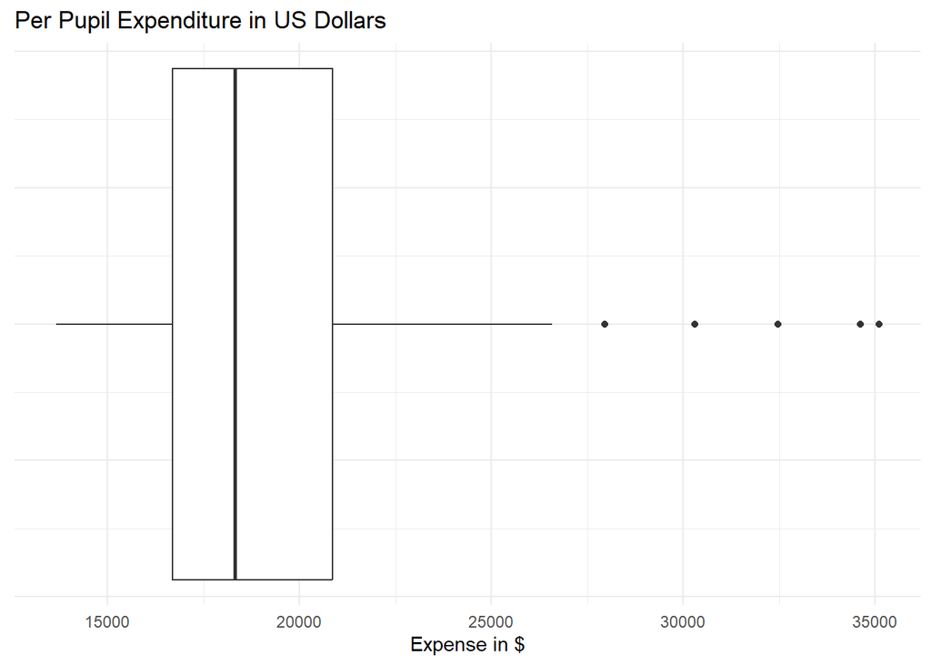

   ```r
   Fig1 <- ggplot(Final_df, aes(Final_df$`Per Pupil Expenditure`))+
     geom_boxplot()+
     labs(title = "Per Pupil Expenditure in US Dollars", x = "Expense in $")+
     theme_minimal()+
     theme(axis.text.y = element_blank(),
           axis.ticks.y = element_blank())

   Fig1
   ```

2. Average Teacher’s Salary:

   This box plot illustrates the average teacher salary in Massachusetts district schools. The median salary for teachers in the state is approximately $85,000, with the first quartile (Q1) and third quartile (Q3) hovering around $75,000 and $90,000, respectively. Outliers range from $50,000 to $1,20,000, indicating potential disparities in teacher salaries.

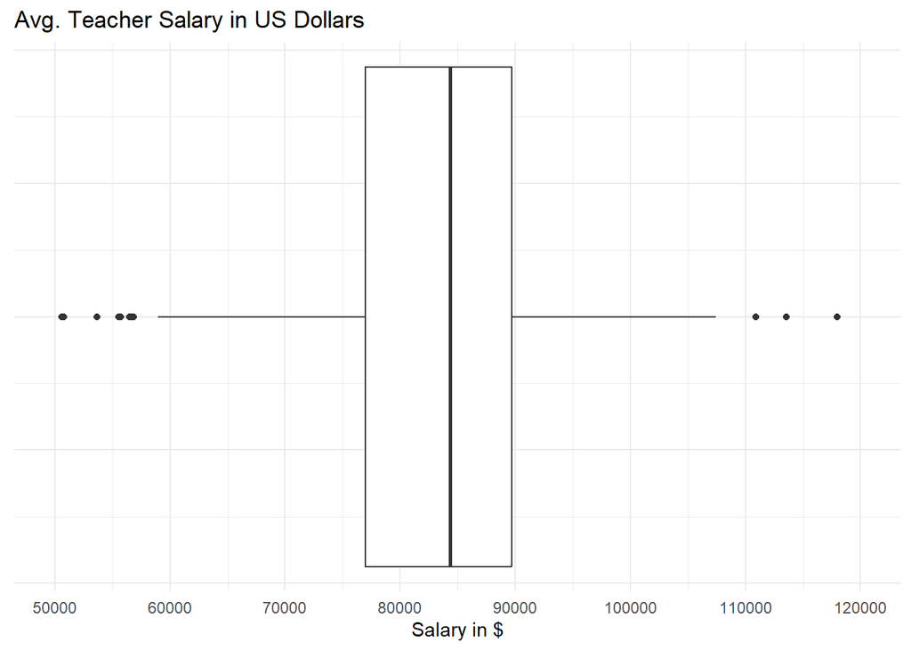

   ```r
   Fig2 <- ggplot(Final_df, aes(Final_df$`Avg. Salary`))+
     geom_boxplot()+
     labs(title = "Avg. Teacher Salary in US Dollars", x = "Salary in $")+
     theme_minimal()+
     theme(axis.text.y = element_blank(),
           axis.ticks.y = element_blank())+
     scale_x_continuous(limits = c(50000,120000), breaks = seq(50000,120000, by = 10000))

   Fig2
   ```

3. Graduation Rates:

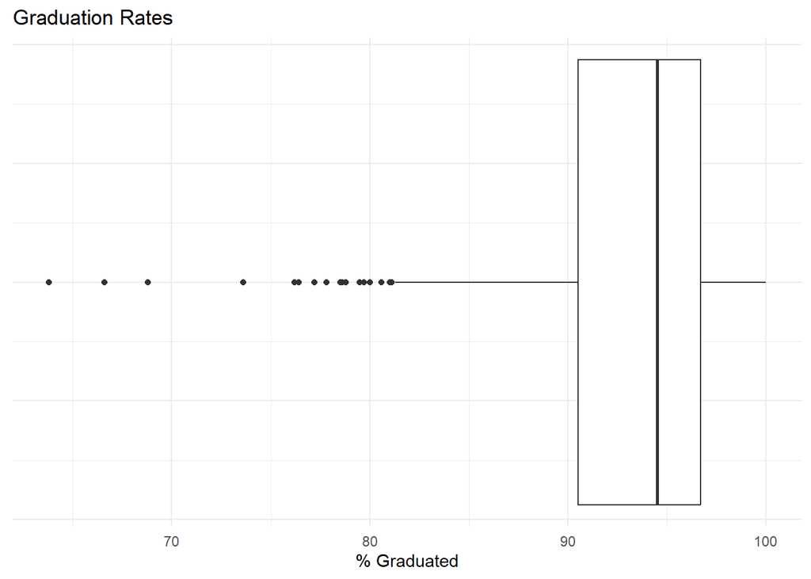

   ```r
   Fig3 <- ggplot(Final_df, aes(Final_df$`% Graduated`))+
     geom_boxplot()+
     labs(title = "Graduation Rates", x = "% Graduated")+
     theme_minimal()+
     theme(axis.text.y = element_blank(),
           axis.ticks.y = element_blank())

   Fig3
   ```

4. Average SAT Scores:

   This box plot illustrates the distribution of average SAT scores across all schools. The median SAT score falls approximately at 560, with the first quartile around 540 and the third quartile around 580. Outliers are observed on both ends of the spectrum, with some schools achieving scores in the range of 660-690, while others score between 410-450.

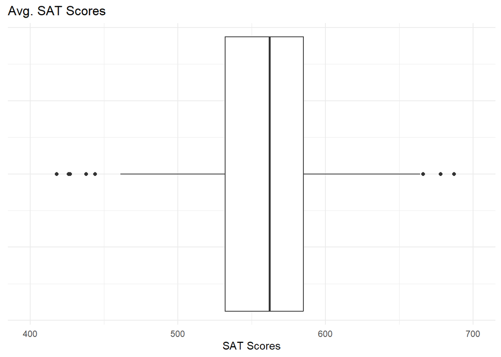

   ```r
   Fig4 <- ggplot(Final_df, aes(Final_df$`Avg SAT Score`))+
     geom_boxplot()+
     labs(title = "Avg. SAT Scores", x = "SAT Scores")+
     theme_minimal()+
     theme(axis.text.y = element_blank(),
           axis.ticks.y = element_blank())+
     scale_x_continuous(limits = c(400,700), breaks = seq(400,700, by = 100))

   Fig4
   ```

5. Low Income:

   This boxplot illustrates the distribution of the percentage of students belonging to a low-income socioeconomic population in our dataset. It is apparent that the median percentage of students belonging to this group is approximately 35% across all schools. The first quartile and third quartile values are approximately 20% and 47%, respectively. Notably, some schools have as much as 88% of students hailing from lower socioeconomic backgrounds, while others have only about 5% of students belonging to such groups.

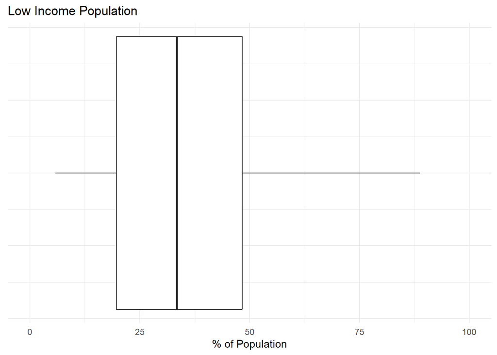

   ```r
   Fig_income <- ggplot(Final_df, aes(Final_df$`Low Income`))+
     geom_boxplot()+
     labs(title = "Low Income Population", x = "% of Population")+
     theme_minimal()+
     theme(axis.text.y = element_blank(),
           axis.ticks.y = element_blank())+
     scale_x_continuous(limits = c(0,100), breaks = seq(0,100, by = 25))

   Fig_income
   ```

## *Scatter plots*

In our research project, scatterplots are invaluable for visually exploring relationships between key variables. They offer a clear way to assess correlations, patterns, and trends in the data. For example, in our analysis of per pupil expenditure and SAT scores in Massachusetts district schools, scatterplots help us identify any potential connections between these factors. By revealing trends and outliers, scatterplots aid in making informed interpretations and hypotheses about the data. Their simplicity and effectiveness make them essential tools for descriptive visualization, enhancing our understanding of the data’s underlying dynamics.

1. Per Pupil Expenditure Vs SAT Scores:

   As illustrated in the scatter plot below, there appears to be no clear linear relationship between per-pupil expenditure and Average SAT scores. Despite variations in per pupil expenses, there is no apparent corresponding increase in Average SAT scores.

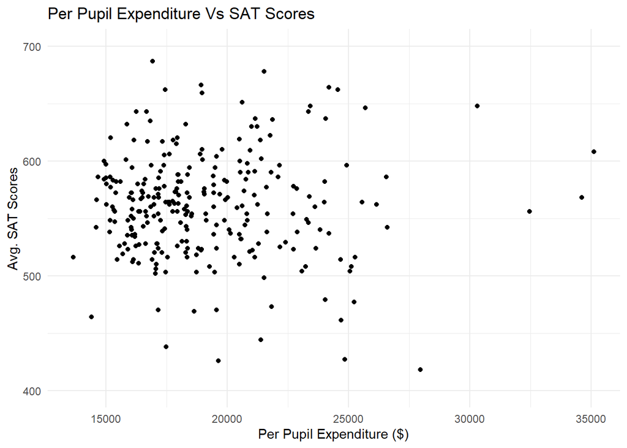

   ```r
   Fig5 <- ggplot(Final_df, aes(Final_df$`Per Pupil Expenditure`, Final_df$`Avg SAT Score`))+
     geom_point()+
     theme_minimal()+
     labs(title = "Per Pupil Expenditure Vs SAT Scores", x = "Per Pupil Expenditure ($)", y = "Avg. SAT Scores")+
     scale_y_continuous(limits = c(400,700), breaks = seq(400,700, by = 100))

   Fig5
   ```

2. Average Teacher’s Salaries Vs Average SAT Scores:

   This scatter plot illustrates the relationship between average teacher salary and average SAT scores. It’s intriguing to observe a somewhat linear trend between these two variables, suggesting that as average teacher salary increases, so do average SAT scores.

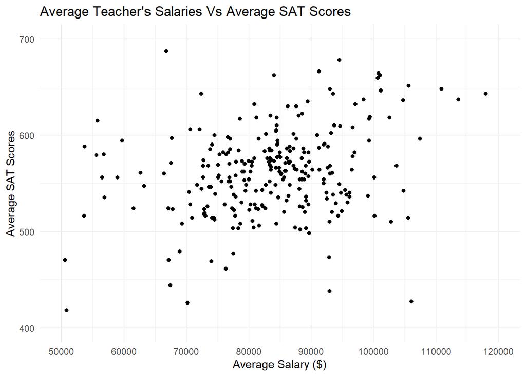

   ```r
   Fig6 <- ggplot(Final_df, aes(x = Final_df$`Avg. Salary`, y = Final_df$`Avg SAT Score`))+
     geom_point()+
     theme_minimal()+
     labs(title = "Average Teacher's Salaries Vs Average SAT Scores", x = "Average Salary ($)", y = "Average SAT Scores")+
     scale_y_continuous(limits = c(400,700), breaks = seq(400,700, by = 100))+
     scale_x_continuous(limits = c(50000,120000), breaks = seq(50000,120000, by = 10000))

   Fig6
   ```

3. Graduation Rates Vs Average SAT Scores:

   The scatter plot below illustrates the correlation between school graduation rates and average SAT scores. It appears that the majority of schools have graduation rates exceeding 80%, with a slight linear trend showing higher SAT scores as graduation rates increase.

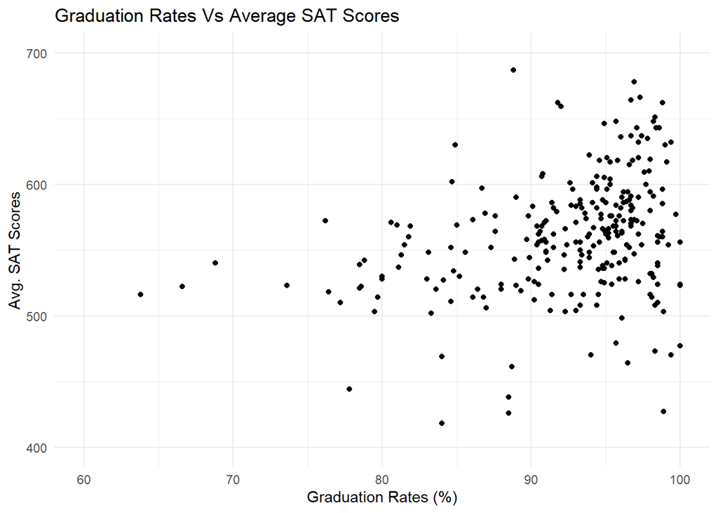

   ```r
   Fig7 <- ggplot(Final_df, aes(x = Final_df$`% Graduated`, y = Final_df$`Avg SAT Score`))+
     geom_point()+
     theme_minimal()+
     labs(title = "Graduation Rates Vs Average SAT Scores", y = "Avg. SAT Scores", x = "Graduation Rates (%)")+
     scale_x_continuous(limits = c(60,100), breaks = seq(60,100, by = 10))+
     scale_y_continuous(limits = c(400,700), breaks = seq(400,700, by = 100))

   Fig7
   ```

4. Per Pupil Expenditure Vs Average Teacher’s Salary:

   The scatter plot below depicts the correlation between per-pupil expenditure and average teacher salaries. It reveals a subtle linear relationship between these two variables, suggesting that higher per-pupil expenses are associated with increased teacher salaries.

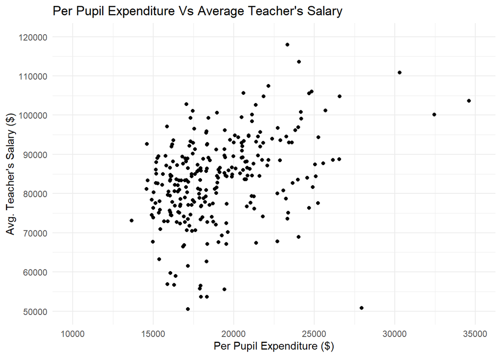

   ```r
   Fig8 <- ggplot(Final_df, aes(x = Final_df$`Per Pupil Expenditure`, y = Final_df$`Avg. Salary`))+
     geom_point()+
     theme_minimal()+
     labs(title = "Per Pupil Expenditure Vs Average Teacher's Salary", x = "Per Pupil Expenditure ($)", y = "Avg. Teacher's Salary ($)")+
     scale_x_continuous(limits = c(10000,35000), breaks = seq(10000,35000, by = 5000))+
     scale_y_continuous(limits = c(50000,120000), breaks = seq(50000,120000, by = 10000))

   Fig8
   ```

5. Per Pupil Expenditure Vs Graduation Rates:

   The scatter plot presented below illustrates the relationship between Per Pupil expenditure and graduation rates of schools. It is evident that a majority of the schools exhibit commendable graduation rates. However, the plot suggests that there is no clear correlation between increasing per pupil expenditure and higher graduation rates. Despite higher expenditure, there appears to be no significant increase in graduation rates, indicating that other factors may play a more influential role in determining graduation outcomes.

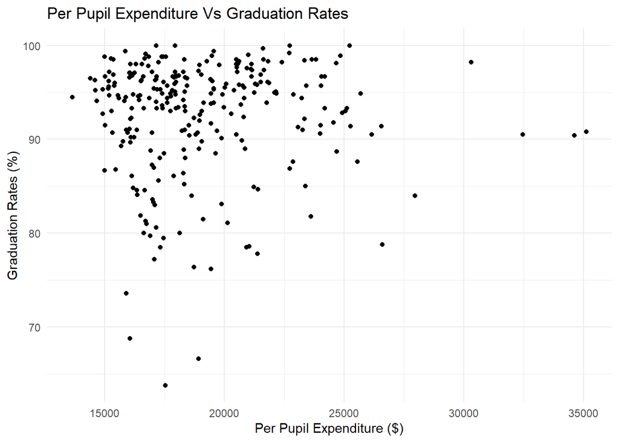

   ```r
   Fig9 <- ggplot(Final_df, aes(x = Final_df$`Per Pupil Expenditure`, y = Final_df$`% Graduated`))+
     geom_point()+
     theme_minimal()+
     labs(title = "Per Pupil Expenditure Vs Graduation Rates", x = "Per Pupil Expenditure ($)", y = "Graduation Rates (%)")

   Fig9
   ```

6. Average Teacher Salaries Vs Graduation Rates:

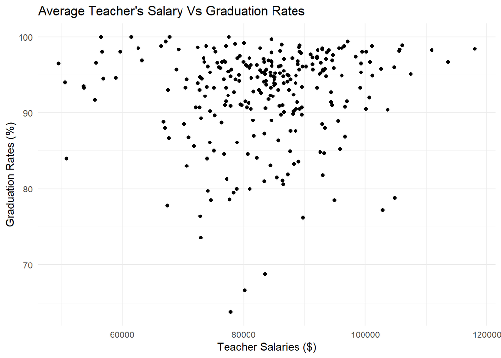

   ```r
   Fig10 <- ggplot(Final_df, aes(x = Final_df$`Avg. Salary`, y = Final_df$`% Graduated`))+
     geom_point()+
     theme_minimal()+
     labs(title = "Average Teacher's Salary Vs Graduation Rates", x = "Teacher Salaries ($)", y = "Graduation Rates (%)")

   Fig10
   ```

Up to this point, our analysis has focused on using the average SAT scores as our dependent variable to explore any potential correlation with expenses. These average scores were derived by combining both math and reading/writing scores. Now, let’s delve deeper into understanding whether expenses exert varying influences on different SAT scores. To accomplish this, we will investigate the impact of expenses on math scores and reading/writing scores separately, treating them as distinct dependent variables.

To achieve this task, we will create a new data frame containing the per pupil expenditures, teacher salaries, and Math and Reading/Writing scores columns separately for each school. We can accomplish this by merging our existing data frame, which we’ve been using for analysis, with the SAT scores data frame.

```r
df_sep <- Final_df %>%
  select(1:4)

df_sep <- inner_join(df_sep, SAT_Per, by = "District Code")

df_sep <- df_sep %>%
  select(-5) %>%
  rename("District Name" = "District Name.x")

head(df_sep)
```

```
# A tibble: 6 × 6
  `District Name`           `District Code` Per Pupil Expenditur…¹ `Avg. Salary`
  <chr>                     <chr>                            <dbl>         <dbl>
1 Abby Kelley Foster Chart… 04450000                        16854.         66422
2 Abington                  00010000                        16143.         92005
3 Acton-Boxborough          06000000                        18915.         91268
4 Advanced Math and Scienc… 04300000                        16675.         72386
5 Agawam                    00050000                        19690.         85887
6 Amesbury                  00070000                        19884.         86626
# ℹ abbreviated name: ¹`Per Pupil Expenditure`
# ℹ 2 more variables: `Reading / Writing` <dbl>, Math <dbl>
```

Now that we have our data frame ready, we can proceed with visualization. We’ll use scatter plots to explore how expenses affect Math scores compared to Reading/Writing scores.

7. Per Pupil Expenditure Vs Math & Reading SAT Scores:

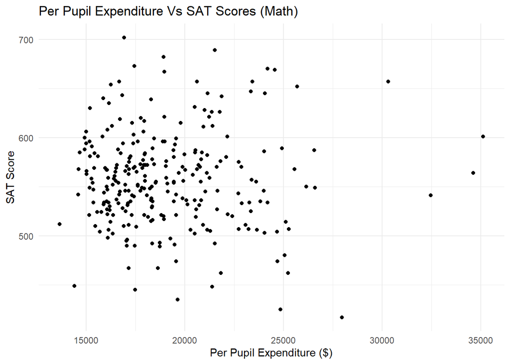

   ```r
   Fig11 <- ggplot(df_sep, aes(x = df_sep$`Per Pupil Expenditure`, y = df_sep$Math))+
     geom_point()+
     theme_minimal()+
     labs(title = "Per Pupil Expenditure Vs SAT Scores (Math)", x = "Per Pupil Expenditure ($)", y = "SAT Score")

   Fig11
   ```

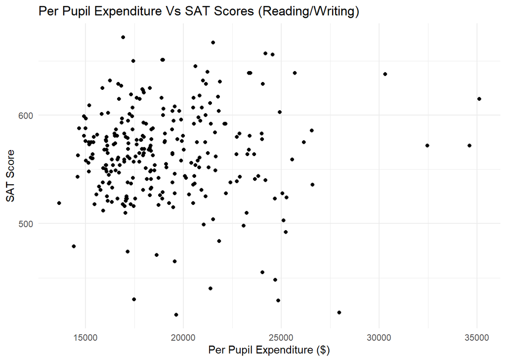

   ```r
   Fig12 <- ggplot(df_sep, aes(x = df_sep$`Per Pupil Expenditure`, y = df_sep$`Reading / Writing`))+
     geom_point()+
     theme_minimal()+
     labs(title = "Per Pupil Expenditure Vs SAT Scores (Reading/Writing)", x = "Per Pupil Expenditure ($)", y = "SAT Score")

   Fig12
   ```

The scatter plots above depict the relationship between per pupil expenditures and SAT scores, with separate plots for Math and Reading/Writing scores. There appears to be no strong correlation between expenditure values and SAT scores for either Math or Reading/Writing. Additionally, there’s little discernible difference between the two subject areas in terms of SAT scores.

Sometimes, assessing the impact of a one-dollar change in an independent variable on the variation in the dependent variable may not provide meaningful insights. In such cases, it’s beneficial to categorize different expense groups based on their central tendencies and descriptive statistics within each school. By doing this, we can compare the influence of expenses on the dependent variable across these groups. To execute this, we’ll categorize schools according to the mean, median, and quartile values of the expense variables. Subsequently, we can visualize and analyze the statistics within these groups.

```r
# Conducting descriptive statistics to determine group boundaries.

summary(Final_df$`Per Pupil Expenditure`)
```

```
   Min. 1st Qu.  Median    Mean 3rd Qu.    Max.
  13661   16705   18320   19120   20858   35114
```

```r
# We can establish four distinct groups: Minimum to 1st Quartile, 1st Quartile to Mean, Mean to 3rd Quartile, and 3rd Quartile to Maximum.
```

```r
# Selecting the required columns and creating a new grouping variable.

df_fac <- Final_df %>%
  select(c(1,2,3,7)) %>%
  mutate(Group = case_when(`Per Pupil Expenditure` == 13661 | `Per Pupil Expenditure` < 16705 ~ 1,
                            `Per Pupil Expenditure` == 16705 | `Per Pupil Expenditure` < 19120 ~ 2,
                            `Per Pupil Expenditure` == 19120 | `Per Pupil Expenditure` < 20858 ~ 3,
                            `Per Pupil Expenditure` == 20858 | `Per Pupil Expenditure` <= 35114 ~ 4

  ))

df_fac # Checking the Sanity of the new data set.
```

```
# A tibble: 269 × 5
   `District Name`  `District Code` Per Pupil Expenditur…¹ `Avg SAT Score` Group
   <chr>            <chr>                            <dbl>           <dbl> <dbl>
 1 Abby Kelley Fos… 04450000                        16854.             560     2
 2 Abington         00010000                        16143.             550     1
 3 Acton-Boxborough 06000000                        18915.             666     2
 4 Advanced Math a… 04300000                        16675.             643     1
 5 Agawam           00050000                        19690.             571     3
 6 Amesbury         00070000                        19884.             583     3
 7 Amherst-Pelham   06050000                        24555.             662     4
 8 Andover          00090000                        20941.             609     4
 9 Arlington        00100000                        17934.             620     2
10 Ashburnham-West… 06100000                        14920.             600     1
# ℹ 259 more rows
# ℹ abbreviated name: ¹`Per Pupil Expenditure`
```

Now that we have created a dataset containing the grouping variables, we can proceed to plot scatterplots between Per Pupil Expenditure and Average SAT scores displayed by different groups of expenditures. The first group consists of schools with per-pupil expenditure ranging from $13,661 to $16,704, the second group from $16,705 to $19,119, the third group from $19,120 to $20,857, and finally, the fourth group from $20,858 to $35,114.

8. Per Pupil Expenditure Vs Average SAT Scores among different Expenses Groups:

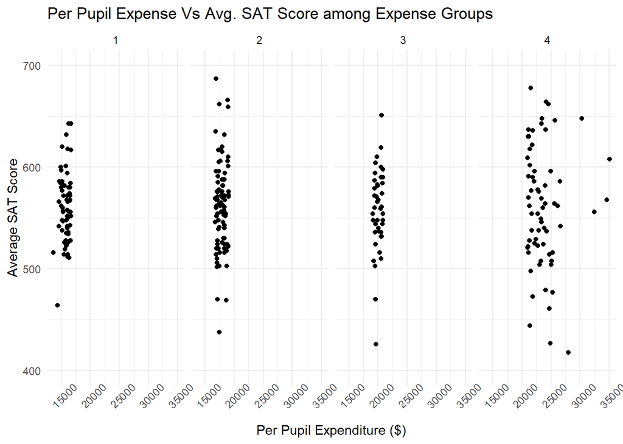

   ```r
   ggplot(df_fac, aes(df_fac$`Per Pupil Expenditure`, df_fac$`Avg SAT Score`))+
     geom_point()+
     theme_minimal()+
     labs(title = "Per Pupil Expense Vs Avg. SAT Score among Expense Groups", x = "Per Pupil Expenditure ($)", y = "Average SAT Score")+
     facet_grid(~ df_fac$Group)+
     theme(axis.text.x = element_text(angle = 45))+
     scale_y_continuous(breaks = c(400,500,600,700), limits = c(400,700, by = 100))
   ```

9. Average SAT Scores Vs Low Income Population:

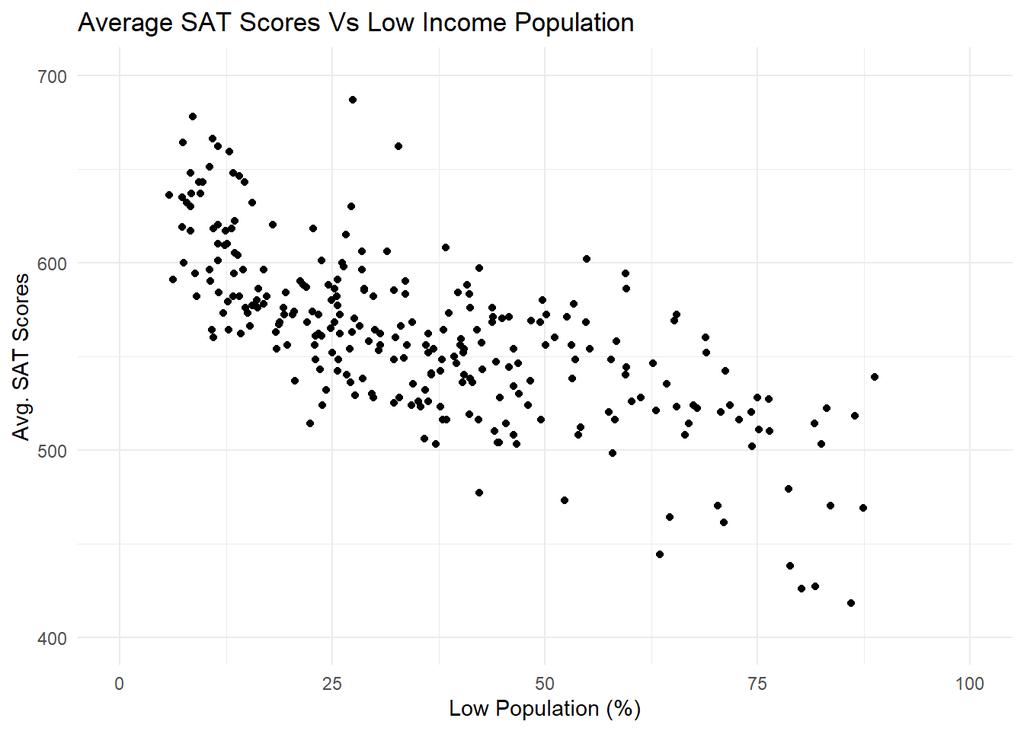

   ```r
   Fig13 <- ggplot(Final_df, aes(x = Final_df$`Low Income`, y = Final_df$`Avg SAT Score`))+
     geom_point()+
     theme_minimal()+
     labs(title = "Average SAT Scores Vs Low Income Population", x = "Low Population (%)", y = "Avg. SAT Scores")+
     scale_y_continuous(breaks = c(400,500,600,700), limits = c(400,700, by = 100))+
     scale_x_continuous(breaks = c(0,25,50,75,100), limits = c(0,100, by = 25))

   Fig13
   ```

The observed negative correlation in the scatter plot between average SAT scores and the percentage of students from low-income populations indicates an inverse relationship, suggesting that as the percentage of students from low-income backgrounds increases, average SAT scores tend to decrease. This finding holds important implications for regression analysis, where the coefficient for the low-income population percentage variable is expected to be negative, reflecting the association between socioeconomic status and SAT performance. Integrating this variable into the regression model can enhance its predictive accuracy by accounting for socioeconomic disparities in educational outcomes. Further investigation into the underlying mechanisms driving this relationship, including factors such as resource allocation and educational support, is warranted to inform more targeted interventions and policy strategies.

## Hypothesis Testing

In my research, I focus on understanding the factors influencing average SAT scores among students in district schools. The key explanatory variable under examination is the per pupil expenditure allocated by these schools. Additionally, I’m investigating the potential impact of two other variables: average teacher salaries and graduation rates from these schools. These variables serve as points of interest, with the hypothesis that they may play a role in influencing SAT scores. Given the observed negative relationship between average SAT scores and the low-income population, this variable can serve as a valuable control variable in our analysis. By including it, we gain a deeper understanding of the factors influencing our dependent variable. Regression analysis allows for a comprehensive examination of these variables, enabling the estimation of their effects on SAT scores while accounting for potential confounding factors. By conducting hypothesis testing using regression analysis, I aim to provide empirical insights into the determinants of SAT performance, informing educational policies and practices.

### Model #1

In this initial model, we will begin by examining the relationship between the key dependent variable, Average SAT score, and the key independent variable, Per pupil expenditure. We will conduct a linear regression analysis using the lm function and analyze the summary statistics to extract meaningful insights.

```r
# Fitting in the model with data.

model_1_h1 <- lm(Final_df$`Avg SAT Score` ~ Final_df$`Per Pupil Expenditure`, data = Final_df)

# Viewing summary statistics of the regression analysis.

summary(model_1_h1)
```

```
Call:
lm(formula = Final_df$`Avg SAT Score` ~ Final_df$`Per Pupil Expenditure`,
    data = Final_df)

Residuals:
     Min       1Q   Median       3Q      Max
-142.449  -28.680    1.147   24.214  126.206

Coefficients:
                                   Estimate Std. Error t value Pr(>|t|)
(Intercept)                       5.613e+02  1.588e+01  35.341   <2e-16 ***
Final_df$`Per Pupil Expenditure` -3.120e-05  8.183e-04  -0.038     0.97
---
Signif. codes:  0 '***' 0.001 '**' 0.01 '*' 0.05 '.' 0.1 ' ' 1

Residual standard error: 44.91 on 267 degrees of freedom
Multiple R-squared:  5.445e-06, Adjusted R-squared:  -0.00374
F-statistic: 0.001454 on 1 and 267 DF,  p-value: 0.9696
```

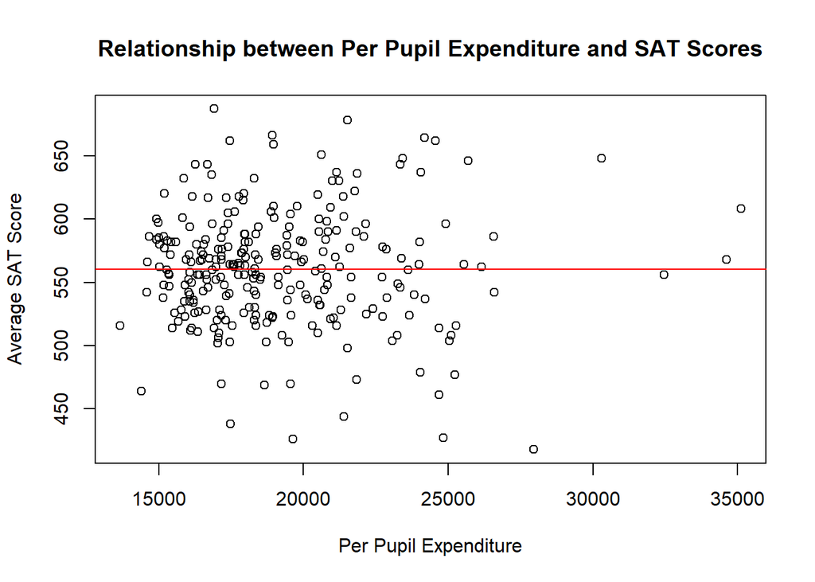

```r
# Scatter plot with regression line

plot(Final_df$`Per Pupil Expenditure`, Final_df$`Avg SAT Score`,
     xlab = "Per Pupil Expenditure", ylab = "Average SAT Score",
     main = "Relationship between Per Pupil Expenditure and SAT Scores")

# Adding a regression line

abline(lm(Final_df$`Avg SAT Score` ~ Final_df$`Per Pupil Expenditure`, data = Final_df), col = "red")
```

```r
# The linear regression line indicates that there is no slope or explanatory power associated with the independent variable.
```

The coefficients table shows the estimates for the intercept and the slope of the regression line.

- Intercept (Estimated Coefficient): The estimated intercept coefficient represents the expected value of the dependent variable when the independent variable is zero. In this case, it suggests that the expected Average SAT score is 561.3 when the Per Pupil Expenditure is zero.

- Per Pupil Expenditure (Estimated Coefficient): The estimated coefficient for Per Pupil Expenditure represents the change in the dependent variable (Average SAT score) for a one-unit increase in the independent variable (Per Pupil Expenditure). Here, it indicates that a one-unit increase in Per Pupil Expenditure leads to a decrease of 0.0000312 in the Average SAT score, although this change is not statistically significant as indicated by the p-value of 0.97.

Additionally, the residual standard error (44.91) represents the standard deviation of the residuals, indicating the average distance of the observed values from the regression line. The Multiple R-squared and Adjusted R-squared values assess the goodness-of-fit of the model, with low values indicating that the independent variable(s) do not explain much of the variability in the dependent variable. Lastly, the F-statistic tests the overall significance of the regression model, with a high p-value (0.9696) indicating that the model is not statistically significant in explaining the variation in the dependent variable.

Based on the analysis above, it’s evident that the model lacks statistical significance, as indicated by the low R-squared value and the high p-value associated with the independent variable. These results suggest that per pupil expenditure alone does not account for the variations observed in the dependent variable, Average SAT scores. To address this limitation, we will incorporate additional control variables into the model to assess whether they enhance the predictive capability and overall performance of the model. The analysis of this model yields significant evidence indicating that we fail to reject the null hypothesis for our first hypothesis, which posits that per-pupil expenditure has no significant relationship with our dependent variable of average SAT scores.